# DLNMs: Getting started

# Problem 1: visualizing the results

Unfortunately `plot.gam()` does not work with these crossbasis functions.

```r
plot.gam(growth)
```

```
## Error in plot.gam(growth): No terms to plot - nothing for plot.gam() to do.
```

The `dlnm` package provides some functions for visualizing the results of a DLNM, though I don’t like them much.

First you use `crosspred()` to get predicted values for the DLNM.

```r
pred_dat <- crosspred("spei_history", growth)
```

```
## centering value unspecified. Automatically set to 0
```

Then you plot those with `plot.crosspred()`. The default is a 3D plot.

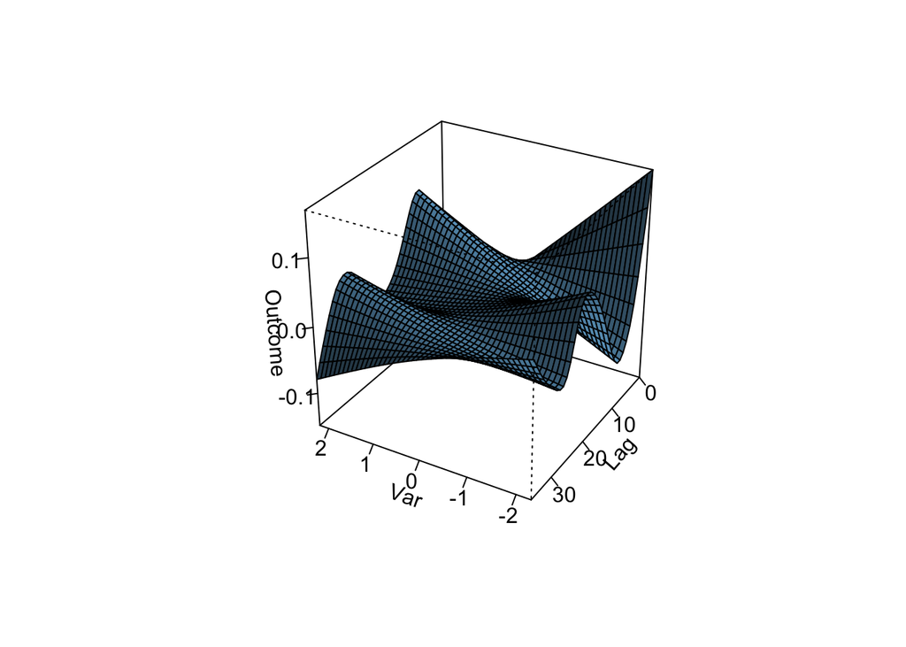

```r
plot(pred_dat)
```

I prefer a heatmap, although the one produced here has some issues.

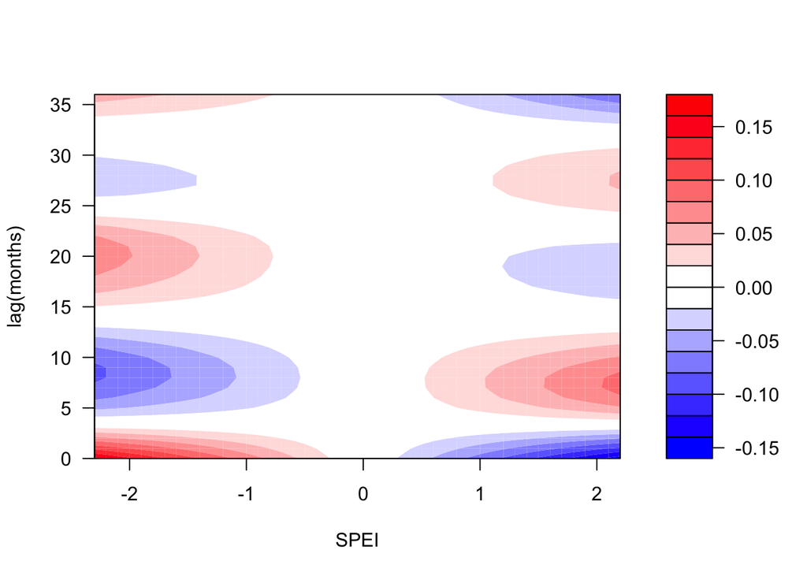

```r
plot(pred_dat, ptype = "contour", xlab = "SPEI", ylab = "lag(months)")
```

First obvious problem is the colors. The range is the same for red and blue, despite different number of breaks. Second, the units are not what I’d expect. For a marginal effects plot these should be the size of an average plant in year t+1, all else being equal. This is plotting the size relative to the size at an average value of SPEI, which is a weird thing to think about. That’s because the package was built with epidemiology and relative risk in mind. Here is the plot relative to SPEI = 1.5

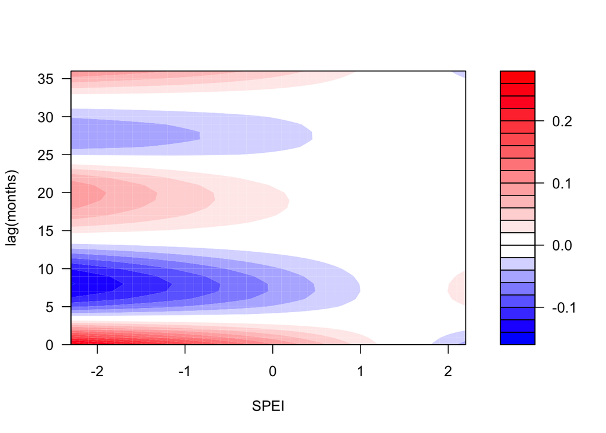

```r
pred_dat <- crosspred("spei_history", growth, cen = 1.5)
plot(pred_dat, ptype = "contour", xlab = "SPEI", ylab = "lag(months)")
```

# Solution (?)

So, I spent a lot of time writing a complicated function, `cb_margeff()`, to create data for a marginal effects plot. It creates a `newdata` data frame to be passed to `predict()` and loops across different matrixes with all columns of `spei_history` set to average except for one, representing a range of possible SPEI values.

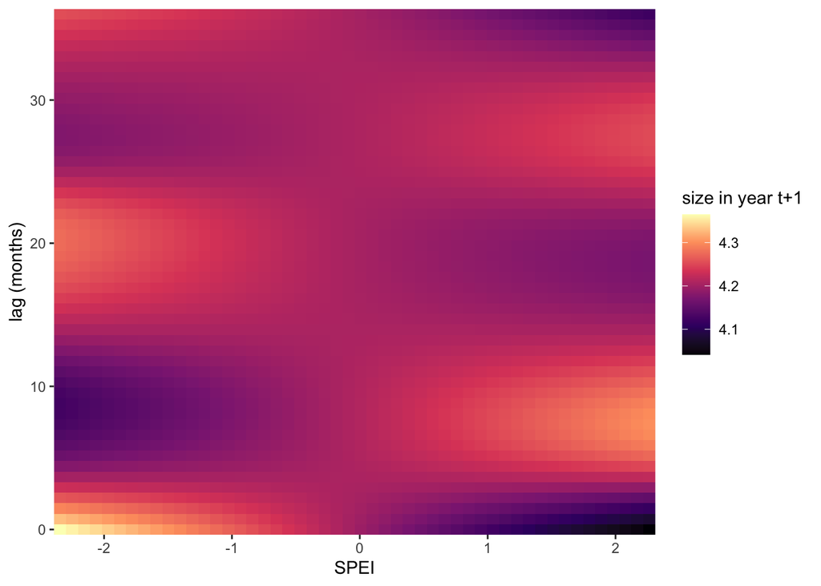

```r
plotdata <- cb_margeff(growth, spei_history, L)
ggplot(plotdata, aes(x = x, y = lag, fill = fitted)) +
  geom_raster() +
  scale_fill_viridis_c("size in year t+1", option = "A") +
  scale_x_continuous("SPEI", expand = c(0,0)) +
  scale_y_continuous("lag (months)", expand = c(0,0))
```

Yeah, this is looking better.

The interpretation of this type of plot (which I would describe as a marginal effects plot, but correct me if I’m wrong) makes more sense to me. If there was drought (low SPEI) about 8 months prior to the census, that’s bad for growth. Drought 20 months prior is good for growth though.

**BUT WAIT**

I poked around in `plot.gam` with `debug()` and it turns out the reason the plotting doesn’t work is only because the author of `dlnm`, Gasparrini, didn’t want it to work.

I can change a simple flag inside the `growth` model, and then it produces something very similar (identical?) to what I have above:

```r
growth$smooth[[1]]$plot.me
```

```
## [1] FALSE
```

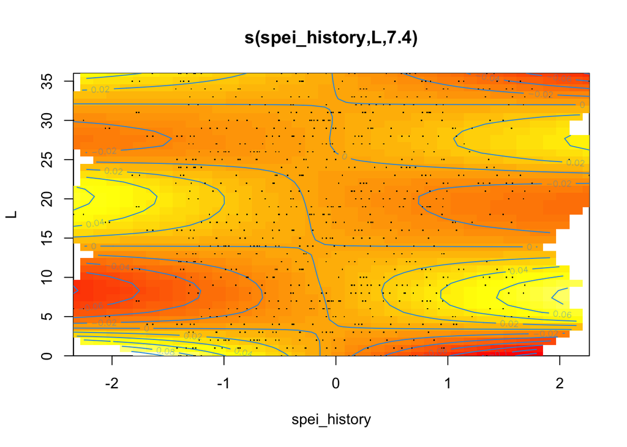

```r
growth$smooth[[1]]$plot.me <- TRUE
plot.gam(growth, scheme = 2)
```

Why is this default plot not available? It’s literally **exactly** what I wanted. Am I doing something wrong here?